# Praktikum 7: Transformasi Box-Cox dalam Analisis Regresi Linear Berganda

Penanganan Asumsi Normalitas Sisaan

Andhias Abdillah Ridhp

26 June 2026

# 1 Asumsi-Asumsi Klasik Regresi Linear

Asumsi sisaan yang harus dipenuhi dari model regresi linear adalah sebagai berikut:

1. Nilai harapan galat sama dengan nol: $E[\varepsilon_i] = 0$
2. Homoskedastisitas atau ragam galat homogen: $\text{Var}[\varepsilon] = \sigma^2 I$
3. Tidak terdapat autokorelasi atau galat saling bebas: $E[\varepsilon_i, \varepsilon_j] = 0$
4. Galat menyebar normal: $\varepsilon \sim N(0, \sigma^2 I)$
5. Tidak terdapat multikolinearitas antarpeubah bebas: $\text{cov}(x_i, x_j) = 0, \forall i \neq j$

Apabila terdapat asumsi sisaan yang dilanggar pada model, maka diperlukan penanganan kondisi tak standar. Salah satu metode yang umum digunakan untuk menangani pelanggaran asumsi normalitas sisaan adalah **transformasi Box-Cox**, yang akan menjadi fokus utama dalam praktikum ini.

# 2 Persiapan

## 2.1 Library

Berikut adalah paket-paket yang digunakan dalam analisis ini beserta fungsinya:

```r
library(dplyr)     # Manipulasi data
library(GGally)    # Visualisasi hubungan antarpeubah
library(psych)     # Analisis data dan korelasi
library(car)       # Uji multikolinearitas dan Durbin-Watson
library(lmtest)    # Uji Breusch-Pagan
library(corrplot)  # Visualisasi matriks korelasi
library(nortest)   # Uji normalitas Lilliefors
library(MASS)      # Transformasi Box-Cox
```

## 2.2 Pemuatan Data

Data yang digunakan dalam analisis ini adalah `state.x77`, yaitu data bawaan perangkat lunak R yang berisi statistik dari 50 negara bagian Amerika Serikat. Peubah respons yang akan dimodelkan adalah `Income` (pendapatan per kapita).

```r
data <- as.data.frame(state.x77)
data <- data %>% dplyr::select(Income, everything())
data <- data[, -7]  # Menghapus peubah Frost
head(data, 10)
```

|  | Income | Population | Illiteracy | Life Exp | Murder | HS Grad | Area |
| --- | --- | --- | --- | --- | --- | --- | --- |
| Alabama | 3624 | 3615 | 2.1 | 69.05 | 15.1 | 41.3 | 50708 |
| Alaska | 6315 | 365 | 1.5 | 69.31 | 11.3 | 66.7 | 566432 |
| Arizona | 4530 | 2212 | 1.8 | 70.55 | 7.8 | 58.1 | 113417 |
| Arkansas | 3378 | 2110 | 1.9 | 70.66 | 10.1 | 39.9 | 51945 |
| California | 5114 | 21198 | 1.1 | 71.71 | 10.3 | 62.6 | 156361 |
| Colorado | 4884 | 2541 | 0.7 | 72.06 | 6.8 | 63.9 | 103766 |
| Connecticut | 5348 | 3100 | 1.1 | 72.48 | 3.1 | 56.0 | 4862 |
| Delaware | 4809 | 579 | 0.9 | 70.06 | 6.2 | 54.6 | 1982 |
| Florida | 4815 | 8277 | 1.3 | 70.66 | 10.7 | 52.6 | 54090 |
| Georgia | 4091 | 4931 | 2.0 | 68.54 | 13.9 | 40.6 | 58073 |

# 3 Pemodelan Regresi Linear

## 3.1 Eksplorasi Data

Sebagai langkah awal analisis, perlu dilakukan eksplorasi terhadap seluruh peubah yang digunakan. Eksplorasi paling dasar dalam proses analisis regresi adalah pengecekan sebaran tiap peubah dan deteksi potensi amatan anomali (pencilan maupun *leverage*). Setiap peubah diharapkan menyebar (atau menyerupai sebaran) normal dan bebas dari amatan anomali.

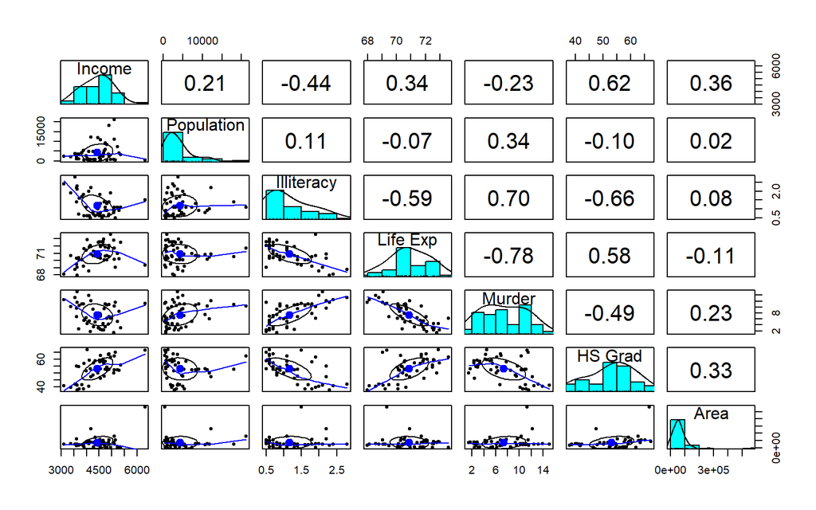

Matriks Scatterplot Antarpeubah

```r
pairs.panels(data)
```

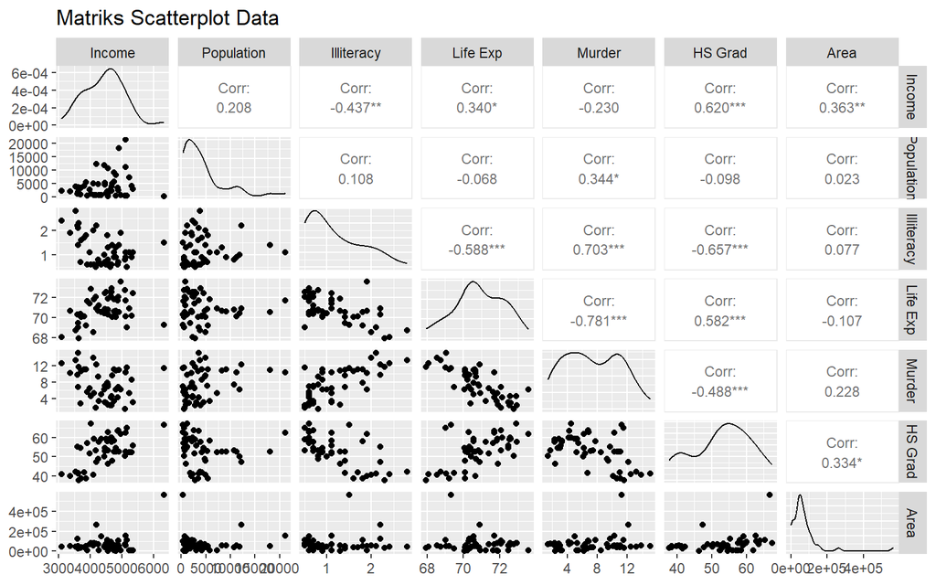

Matriks Scatterplot dengan ggpairs

```r
ggpairs(
  data,
  upper = list(continuous = wrap("cor", size = 3)),
  title = "Matriks Scatterplot Data"
)
```

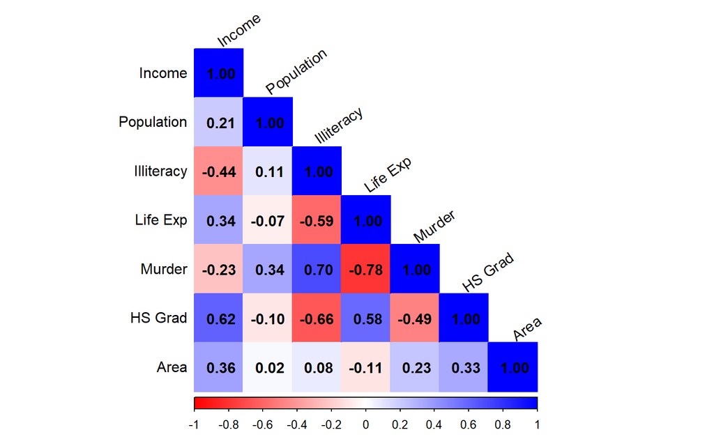

Heatmap Korelasi Antarpeubah

```r
cor_matrix <- cor(data, use = "complete.obs")
corrplot(
  cor_matrix,
  method = "color",
  type = "lower",
  col = colorRampPalette(c("red", "white", "blue"))(200),
  addCoef.col = "black",
  tl.col = "black",
  tl.srt = 35
)
```

Hasil eksplorasi terhadap hubungan setiap peubah penjelas dengan peubah respons menyatakan bahwa peubah `Income` memiliki hubungan positif terhadap `Population`, `Life Exp`, `HS Grad`, dan `Area`, serta hubungan negatif terhadap `Illiteracy` dan `Murder`.

## 3.2 Pemodelan Awal

### 3.2.1 Pengujian Multikolinearitas

Sebelum membentuk model regresi, perlu dilakukan pemeriksaan multikolinearitas antarpeubah penjelas menggunakan nilai *Variance Inflation Factor* (VIF). Apabila nilai VIF lebih besar dari 10, maka terdapat indikasi multikolinearitas yang serius.

```r
model <- lm(Income ~ ., data = data)
(vif_model <- vif(model))
```

```
#> Population Illiteracy `Life Exp`     Murder  `HS Grad`       Area
#>   1.368406   2.974850   3.510591   4.852331   2.955145   1.539652
```

Setelah dilakukan pengujian, diketahui bahwa **tidak terdapat multikolinearitas** antarpeubah penjelas. Hal ini diindikasikan oleh nilai VIF $< 10$ pada seluruh peubah penjelas yang digunakan.

### 3.2.2 Ringkasan Model Penuh

```r
summary(model)
```

```
#>
#> Call:
#> lm(formula = Income ~ ., data = data)
#>
#> Residuals:
#>     Min      1Q  Median      3Q     Max
#> -896.22 -229.39  -51.62  233.70  963.04
#>
#> Coefficients:
#>               Estimate Std. Error t value Pr(>|t|)
#> (Intercept)  3.411e+03  6.457e+03   0.528   0.6000
#> Population   3.960e-02  1.739e-02   2.277   0.0278 *
#> Illiteracy  -1.557e+02  1.878e+02  -0.829   0.4116
#> `Life Exp`  -1.114e+01  9.265e+01  -0.120   0.9048
#> Murder      -1.255e+01  3.961e+01  -0.317   0.7529
#> `HS Grad`    3.392e+01  1.413e+01   2.401   0.0208 *
#> Area         1.690e-03  9.653e-04   1.751   0.0872 .
#> ---
#> Signif. codes:  0 '***' 0.001 '**' 0.01 '*' 0.05 '.' 0.1 ' ' 1
#>
#> Residual standard error: 464.7 on 43 degrees of freedom
#> Multiple R-squared:  0.4982, Adjusted R-squared:  0.4281
#> F-statistic: 7.114 on 6 and 43 DF,  p-value: 2.618e-05
```

Pemodelan menggunakan seluruh peubah menyiratkan bahwa hanya peubah penjelas `Population` dan `HS Grad` yang berpengaruh signifikan pada taraf nyata 5% terhadap peubah respons `Income`. Oleh karena itu, perlu dilakukan penyeleksian peubah agar model yang dihasilkan terbaik dalam hal signifikansi peubah.

# 4 Seleksi Peubah

## 4.1 Metode Backward Elimination

Prosedur seleksi peubah dengan metode *backward elimination* berjalan sebagai berikut:

1. Pemodelan dimulai dengan melibatkan seluruh peubah penjelas yang tersedia.
2. Satu per satu peubah penjelas dieliminasi berdasarkan nilai F-parsial yang paling besar (paling tidak berpengaruh signifikan) terhadap peubah respons.
3. Peubah penjelas yang telah dieliminasi tidak akan dikembalikan ke dalam model.
4. Eliminasi peubah penjelas terus dilakukan hingga diperoleh model terbaik berdasarkan metrik yang diacu (umumnya AIC).

```r
step(lm(Income ~ ., data = data), direction = "backward")
```

```
#> Start:  AIC=620.59
#> Income ~ Population + Illiteracy + `Life Exp` + Murder + `HS Grad` +
#>     Area
#>
#>              Df Sum of Sq      RSS    AIC
#> - `Life Exp`  1      3123  9287803 618.61
#> - Murder      1     21669  9306348 618.71
#> - Illiteracy  1    148423  9433102 619.39
#> <none>                     9284679 620.59
#> - Area        1    661657  9946336 622.03
#> - Population  1   1119285 10403965 624.28
#> - `HS Grad`   1   1244587 10529267 624.88
#>
#> Step:  AIC=618.61
#> Income ~ Population + Illiteracy + Murder + `HS Grad` + Area
#>
#>              Df Sum of Sq      RSS    AIC
#> - Murder      1     22308  9310111 616.73
#> - Illiteracy  1    165140  9452943 617.49
#> <none>                     9287803 618.61
#> - Area        1    677009  9964812 620.13
#> - Population  1   1236798 10524600 622.86
#> - `HS Grad`   1   1416372 10704174 623.71
#>
#> Step:  AIC=616.73
#> Income ~ Population + Illiteracy + `HS Grad` + Area
#>
#>              Df Sum of Sq      RSS    AIC
#> - Illiteracy  1    307844  9617955 616.36
#> <none>                     9310111 616.73
#> - Area        1    670178  9980289 618.20
#> - Population  1   1306229 10616339 621.29
#> - `HS Grad`   1   1555728 10865839 622.46
#>
#> Step:  AIC=616.36
#> Income ~ Population + `HS Grad` + Area
#>
#>              Df Sum of Sq      RSS    AIC
#> <none>                     9617955 616.36
#> - Area        1    418138 10036092 616.48
#> - Population  1   1262741 10880696 620.52
#> - `HS Grad`   1   5700334 15318289 637.63
```

```
#>
#> Call:
#> lm(formula = Income ~ Population + `HS Grad` + Area, data = data)
#>
#> Coefficients:
#> (Intercept)   Population    `HS Grad`         Area
#>   1.807e+03    3.620e-02    4.508e+01    1.150e-03
```

Berdasarkan prosedur seleksi peubah dengan metode *backward*, model terbaik yang terbentuk adalah model dengan tiga peubah penjelas, yaitu `Population`, `HS Grad`, dan `Area`.

## 4.2 Metode Forward Selection

Prosedur seleksi peubah dengan metode *forward selection* berjalan sebagai berikut:

1. Pemodelan dimulai hanya dengan intersep.
2. Satu per satu peubah penjelas dimasukkan ke dalam model berdasarkan nilai koefisien korelasi yang paling besar terhadap peubah respons.
3. Peubah penjelas yang telah dimasukkan tidak akan dieliminasi dari model.
4. Imputasi peubah penjelas terus dilakukan hingga diperoleh model terbaik berdasarkan metrik yang diacu (umumnya AIC).

```r
step(
  lm(Income ~ 1, data = data),
  direction = "forward",
  scope = ~ Population + Illiteracy + `Life Exp` + Murder + `HS Grad` + Area
)
```

```
#> Start:  AIC=643.07
#> Income ~ 1
#>
#>              Df Sum of Sq      RSS    AIC
#> + `HS Grad`   1   7110267 11390825 620.81
#> + Illiteracy  1   3534351 14966741 634.47
#> + Area        1   2442109 16058983 637.99
#> + `Life Exp`  1   2141940 16359152 638.91
#> + Murder      1    979368 17521724 642.35
#> + Population  1    802184 17698908 642.85
#> <none>                    18501092 643.07
#>
#> Step:  AIC=620.81
#> Income ~ `HS Grad`
#>
#>              Df Sum of Sq      RSS    AIC
#> + Population  1   1354732 10036092 616.48
#> + Area        1    510129 10880696 620.52
#> <none>                    11390825 620.81
#> + Murder      1    127398 11263427 622.25
#> + Illiteracy  1     28654 11362170 622.69
#> + `Life Exp`  1     11969 11378856 622.76
#>
#> Step:  AIC=616.48
#> Income ~ `HS Grad` + Population
#>
#>              Df Sum of Sq      RSS    AIC
#> + Area        1    418138  9617955 616.36
#> <none>                    10036092 616.48
#> + Illiteracy  1     55804  9980289 618.20
#> + `Life Exp`  1      8837 10027256 618.44
#> + Murder      1      1733 10034359 618.48
#>
#> Step:  AIC=616.36
#> Income ~ `HS Grad` + Population + Area
#>
#>              Df Sum of Sq     RSS    AIC
#> <none>                    9617955 616.36
#> + Illiteracy  1    307844 9310111 616.73
#> + Murder      1    165012 9452943 617.49
#> + `Life Exp`  1     30414 9587541 618.20
```

```
#>
#> Call:
#> lm(formula = Income ~ `HS Grad` + Population + Area, data = data)
#>
#> Coefficients:
#> (Intercept)    `HS Grad`   Population         Area
#>   1.807e+03    4.508e+01    3.620e-02    1.150e-03
```

Berdasarkan prosedur seleksi peubah dengan metode *forward*, model terbaik yang terbentuk adalah model dengan tiga peubah penjelas yang sama, yaitu `Population`, `HS Grad`, dan `Area`.

## 4.3 Metode Stepwise

Prosedur seleksi peubah *stepwise* merupakan kombinasi antara metode *backward* dan *forward*. Model pertama yang dibentuk adalah model dengan seluruh peubah penjelas yang kemudian akan dieliminasi satu per satu. Meskipun demikian, peubah yang telah dieliminasi masih memiliki kemungkinan untuk diimputasi kembali ke dalam model.

```r
step(lm(Income ~ ., data = data), direction = "both")
```

```
#> Start:  AIC=620.59
#> Income ~ Population + Illiteracy + `Life Exp` + Murder + `HS Grad` +
#>     Area
#>
#>              Df Sum of Sq      RSS    AIC
#> - `Life Exp`  1      3123  9287803 618.61
#> - Murder      1     21669  9306348 618.71
#> - Illiteracy  1    148423  9433102 619.39
#> <none>                     9284679 620.59
#> - Area        1    661657  9946336 622.03
#> - Population  1   1119285 10403965 624.28
#> - `HS Grad`   1   1244587 10529267 624.88
#>
#> Step:  AIC=618.61
#> Income ~ Population + Illiteracy + Murder + `HS Grad` + Area
#>
#>              Df Sum of Sq      RSS    AIC
#> - Murder      1     22308  9310111 616.73
#> - Illiteracy  1    165140  9452943 617.49
#> <none>                     9287803 618.61
#> - Area        1    677009  9964812 620.13
#> + `Life Exp`  1      3123  9284679 620.59
#> - Population  1   1236798 10524600 622.86
#> - `HS Grad`   1   1416372 10704174 623.71
#>
#> Step:  AIC=616.73
#> Income ~ Population + Illiteracy + `HS Grad` + Area
#>
#>              Df Sum of Sq      RSS    AIC
#> - Illiteracy  1    307844  9617955 616.36
#> <none>                     9310111 616.73
#> - Area        1    670178  9980289 618.20
#> + Murder      1     22308  9287803 618.61
#> + `Life Exp`  1      3762  9306348 618.71
#> - Population  1   1306229 10616339 621.29
#> - `HS Grad`   1   1555728 10865839 622.46
#>
#> Step:  AIC=616.36
#> Income ~ Population + `HS Grad` + Area
#>
#>              Df Sum of Sq      RSS    AIC
#> <none>                     9617955 616.36
#> - Area        1    418138 10036092 616.48
#> + Illiteracy  1    307844  9310111 616.73
#> + Murder      1    165012  9452943 617.49
#> + `Life Exp`  1     30414  9587541 618.20
#> - Population  1   1262741 10880696 620.52
#> - `HS Grad`   1   5700334 15318289 637.63
```

```
#>
#> Call:
#> lm(formula = Income ~ Population + `HS Grad` + Area, data = data)
#>
#> Coefficients:
#> (Intercept)   Population    `HS Grad`         Area
#>   1.807e+03    3.620e-02    4.508e+01    1.150e-03
```

Berdasarkan prosedur seleksi peubah dengan metode *stepwise*, model terbaik yang terbentuk konsisten dengan kedua metode sebelumnya, yaitu model dengan tiga peubah penjelas: `Population`, `HS Grad`, dan `Area`.

## 4.4 Model Terbaik

```r
model2 <- lm(Income ~ Population + `HS Grad` + Area, data = data)
summary(model2)
```

```
#>
#> Call:
#> lm(formula = Income ~ Population + `HS Grad` + Area, data = data)
#>
#> Residuals:
#>     Min      1Q  Median      3Q     Max
#> -956.47 -225.60  -14.54  198.88  974.12
#>
#> Coefficients:
#>              Estimate Std. Error t value Pr(>|t|)
#> (Intercept) 1.807e+03  4.581e+02   3.944 0.000272 ***
#> Population  3.620e-02  1.473e-02   2.458 0.017820 *
#> `HS Grad`   4.508e+01  8.634e+00   5.221 4.17e-06 ***
#> Area        1.150e-03  8.135e-04   1.414 0.164049
#> ---
#> Signif. codes:  0 '***' 0.001 '**' 0.01 '*' 0.05 '.' 0.1 ' ' 1
#>
#> Residual standard error: 457.3 on 46 degrees of freedom
#> Multiple R-squared:  0.4801, Adjusted R-squared:  0.4462
#> F-statistic: 14.16 on 3 and 46 DF,  p-value: 1.137e-06
```

Persamaan regresi yang terbentuk dari hasil penyeleksian peubah adalah sebagai berikut:

$$\hat{Y} = 1807 + 0{,}0362\,X_1 + 45{,}08\,X_2 + 0{,}00115\,X_3$$

dengan $X_1 = \text{Population}$, $X_2 = \text{HS Grad}$, dan $X_3 = \text{Area}$.

Dari ketiga peubah tersebut, hanya `Area` yang tidak signifikan pada taraf nyata 5%. Nilai *adjusted* $R^2$ sedikit meningkat dari model dengan seluruh peubah, yakni menjadi $0{,}4462$.

# 5 Diagnostik Sisaan

## 5.1 Eksplorasi Grafik

### 5.1.1 Plot Sisaan terhadap Nilai Dugaan

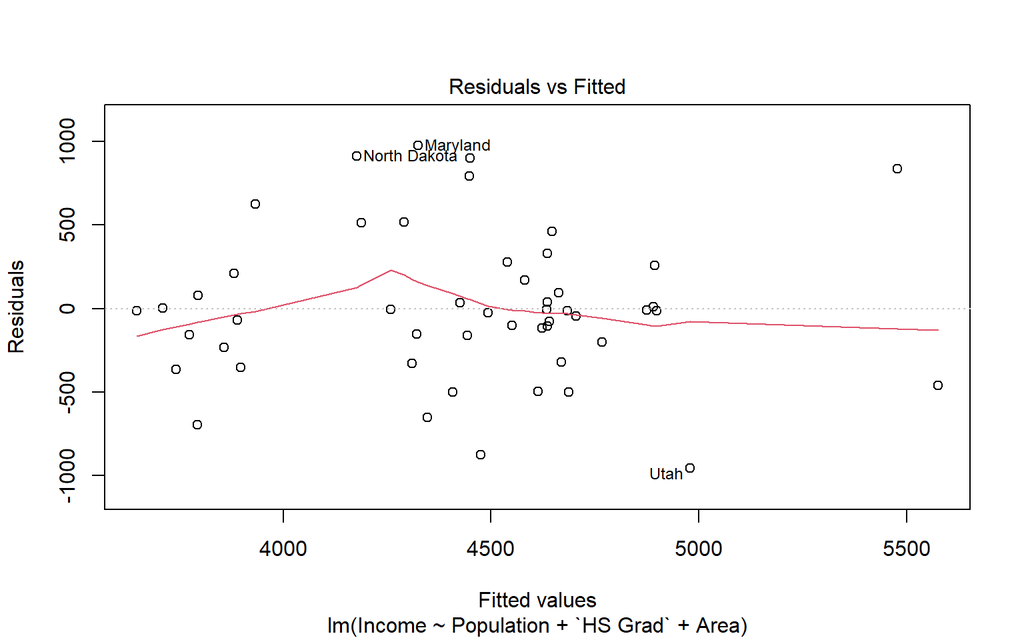

Plot Sisaan vs Nilai Dugaan

```r
plot(model2, 1)
```

Interpretasi plot di atas adalah sebagai berikut:

1. Sisaan tersebar di sekitar nol $\rightarrow$ nilai harapan sisaan sama dengan nol.
2. Lebar pita relatif sama untuk setiap nilai dugaan $\rightarrow$ ragam sisaan homogen.
3. Pola plot acak $\rightarrow$ model sudah pas dan ragam sisaan homogen.

### 5.1.2 Plot Sisaan terhadap Urutan Pengamatan

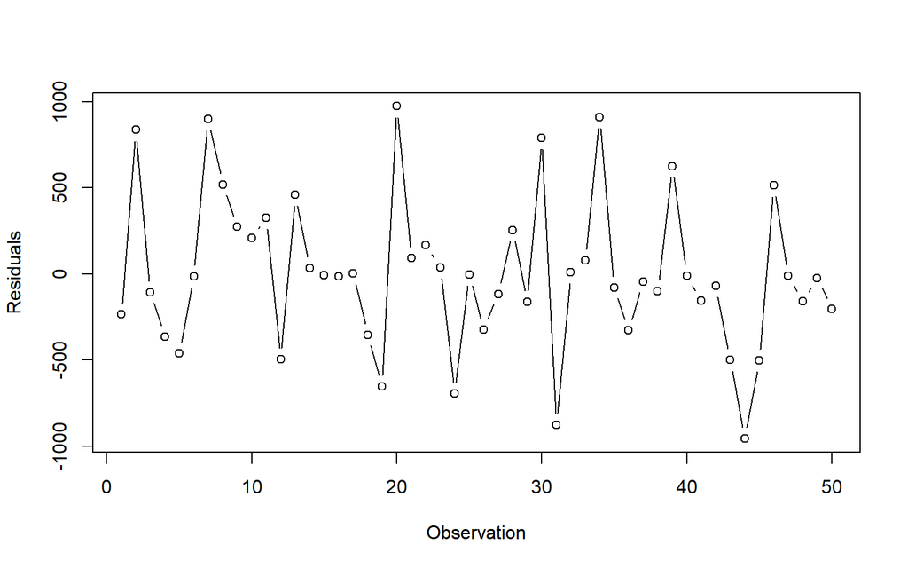

Plot Sisaan vs Urutan Pengamatan

```r
plot(
  x = 1:dim(data)[1],
  y = model2$residuals,
  type = "b",
  ylab = "Residuals",
  xlab = "Observation"
)
```

Tebaran tidak menunjukkan pola tertentu, yang berarti sisaan saling bebas dan model sudah pas.

### 5.1.3 Normal Q-Q Plot

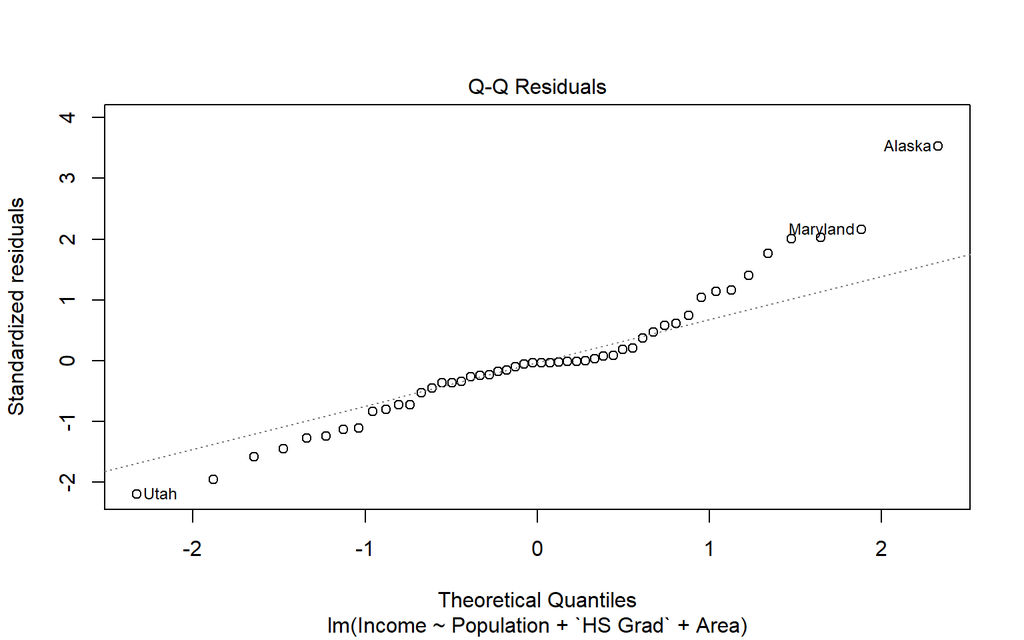

Normal Q-Q Plot Sisaan

```r
plot(model2, 2)
```

Amatan cenderung mengikuti garis pola, sehingga secara visual sisaan terlihat menyebar normal.

## 5.2 Uji Formal

### 5.2.1 Uji Nilai Harapan Sisaan Sama dengan Nol

```r
t.test(model2$residuals, mu = 0, conf.level = 0.95)
```

```
#>
#>  One Sample t-test
#>
#> data:  model2$residuals
#> t = -4.1368e-16, df = 49, p-value = 1
#> alternative hypothesis: true mean is not equal to 0
#> 95 percent confidence interval:
#>  -125.9107  125.9107
#> sample estimates:
#>     mean of x
#> -2.591954e-14
```

Nilai-$p$ pada uji $t$ sama dengan $1$, yang lebih besar daripada $\alpha = 5\%$. Dengan demikian, asumsi nilai harapan sisaan sama dengan nol **terpenuhi**.

### 5.2.2 Uji Homoskedastisitas (Breusch-Pagan)

```r
bptest(model2)
```

```
#>
#>  studentized Breusch-Pagan test
#>
#> data:  model2
#> BP = 3.3253, df = 3, p-value = 0.3441
```

Nilai-$p$ pada uji Breusch-Pagan sama dengan $0{,}3441$, yang lebih besar daripada $\alpha = 5\%$. Dengan demikian, asumsi ragam sisaan homogen **terpenuhi**.

### 5.2.3 Uji Autokorelasi (Durbin-Watson)

```r
dwtest(model2)
```

```
#>
#>  Durbin-Watson test
#>
#> data:  model2
#> DW = 2.0268, p-value = 0.5386
#> alternative hypothesis: true autocorrelation is greater than 0
```

Nilai-$p$ pada uji Durbin-Watson sama dengan $0{,}5386$, yang lebih besar daripada $\alpha = 5\%$. Dengan demikian, asumsi sisaan saling bebas **terpenuhi**.

### 5.2.4 Uji Normalitas Sisaan

```r
lillie.test(model2$residuals)  # Cocok untuk ukuran sampel sedang
```

```
#>
#>  Lilliefors (Kolmogorov-Smirnov) normality test
#>
#> data:  model2$residuals
#> D = 0.14525, p-value = 0.01007
```

```r
shapiro.test(model2$residuals) # Cocok untuk ukuran sampel kecil
```

```
#>
#>  Shapiro-Wilk normality test
#>
#> data:  model2$residuals
#> W = 0.9611, p-value = 0.09886
```

Nilai-$p$ pada uji Shapiro-Wilk sama dengan $0{,}0989$ (lebih besar dari $\alpha = 5\%$), tetapi nilai-$p$ pada uji Lilliefors sama dengan $0{,}0101$ (lebih kecil dari $\alpha = 5\%$). Pada praktikum ini, hasil uji Lilliefors yang digunakan agar dapat diterapkan penanganan asumsi. Dengan demikian, asumsi **normalitas sisaan tidak terpenuhi** dan perlu dilakukan penanganan.

# 6 Penanganan Pelanggaran Asumsi Normalitas

## 6.1 Konsep Transformasi Box-Cox

Salah satu langkah penanganan kondisi tak standar berupa pelanggaran asumsi normalitas sisaan adalah transformasi peubah respons. Metode transformasi yang umum digunakan adalah metode **Box-Cox** dengan rumus transformasi sebagai berikut:

$$y' =
\begin{cases}
\dfrac{y^\lambda - 1}{\lambda}, & \text{jika } \lambda \neq 0
\\[6pt]
\ln(y), & \text{jika } \lambda = 0
\end{cases}$$

Parameter $\lambda$ optimum diperoleh dengan memaksimumkan fungsi *log-likelihood*.

## 6.2 Penentuan Lambda Optimum

```r
bc_model <- boxcox(
  Income ~ Population + `HS Grad` + Area,
  data = data,
  lambda = seq(-2, 2, by = 0.1)
)
```

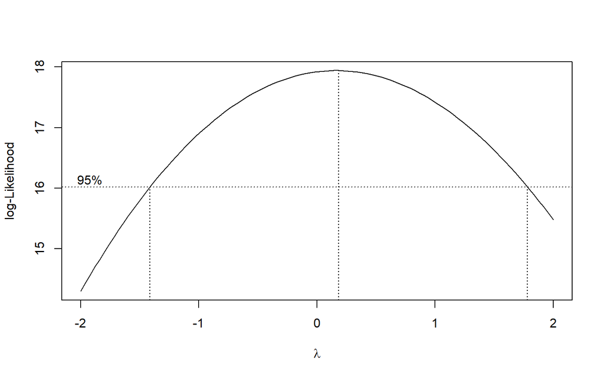

Plot Log-Likelihood terhadap Lambda

```r
(optimal_lambda <- bc_model$x[which.max(bc_model$y)])
```

```
#> [1] 0.1818182
```

Berdasarkan grafik di atas, diketahui bahwa $\lambda$ optimum bernilai $0{,}18182$.

## 6.3 Transformasi Peubah Respons

Selanjutnya, dilakukan transformasi peubah respons menggunakan $\lambda$ optimum yang telah diperoleh.

```r
data$Income_tr <- ((data$Income)^optimal_lambda) - 1/optimal_lambda

data2 <- data[, -1] %>% dplyr::select(Income_tr, everything())
head(data2, 10)
```

|  | Income_tr | Population | Illiteracy | Life Exp | Murder | HS Grad | Area |
| --- | --- | --- | --- | --- | --- | --- | --- |
| Alabama | -1.0626353 | 3615 | 2.1 | 69.05 | 15.1 | 41.3 | 50708 |
| Alaska | -0.5911815 | 365 | 1.5 | 69.31 | 11.3 | 66.7 | 566432 |
| Arizona | -0.8789025 | 2212 | 1.8 | 70.55 | 7.8 | 58.1 | 113417 |
| Arkansas | -1.1189876 | 2110 | 1.9 | 70.66 | 10.1 | 39.9 | 51945 |
| California | -0.7758886 | 21198 | 1.1 | 71.71 | 10.3 | 62.6 | 156361 |
| Colorado | -0.8152493 | 2541 | 0.7 | 72.06 | 6.8 | 63.9 | 103766 |
| Connecticut | -0.7373027 | 3100 | 1.1 | 72.48 | 3.1 | 56.0 | 4862 |
| Delaware | -0.8284123 | 579 | 0.9 | 70.06 | 6.2 | 54.6 | 1982 |
| Florida | -0.8273531 | 8277 | 1.3 | 70.66 | 10.7 | 52.6 | 54090 |
| Georgia | -0.9637574 | 4931 | 2.0 | 68.54 | 13.9 | 40.6 | 58073 |

# 7 Diagnostik Sisaan Setelah Transformasi

Setelah dilakukan transformasi Box-Cox pada peubah respons, langkah berikutnya adalah membangun ulang model regresi dan melakukan diagnostik sisaan terhadap data yang telah ditransformasi.

## 7.1 Pemodelan Ulang

```r
model3 <- lm(
  Income_tr ~ Population + Illiteracy + `HS Grad` + Area,
  data = data2
)
summary(model3)
```

```
#>
#> Call:
#> lm(formula = Income_tr ~ Population + Illiteracy + `HS Grad` +
#>     Area, data = data2)
#>
#> Residuals:
#>      Min       1Q   Median       3Q      Max
#> -0.17214 -0.04344 -0.01139  0.03982  0.16858
#>
#> Coefficients:
#>               Estimate Std. Error t value Pr(>|t|)
#> (Intercept) -1.252e+00  1.457e-01  -8.597 4.74e-11 ***
#> Population   7.421e-06  2.742e-06   2.706  0.00959 **
#> Illiteracy  -4.178e-02  2.913e-02  -1.434  0.15837
#> `HS Grad`    6.577e-03  2.326e-03   2.827  0.00698 **
#> Area         2.476e-07  1.664e-07   1.488  0.14371
#> ---
#> Signif. codes:  0 '***' 0.001 '**' 0.01 '*' 0.05 '.' 0.1 ' ' 1
#>
#> Residual standard error: 0.08508 on 45 degrees of freedom
#> Multiple R-squared:  0.5115, Adjusted R-squared:  0.4681
#> F-statistic: 11.78 on 4 and 45 DF,  p-value: 1.247e-06
```

## 7.2 Eksplorasi Grafik

### 7.2.1 Plot Sisaan terhadap Nilai Dugaan

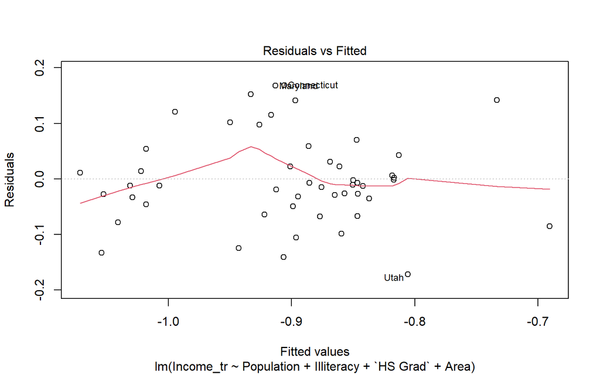

Plot Sisaan vs Nilai Dugaan Setelah Transformasi

```r
plot(model3, 1)
```

### 7.2.2 Plot Sisaan terhadap Urutan Pengamatan

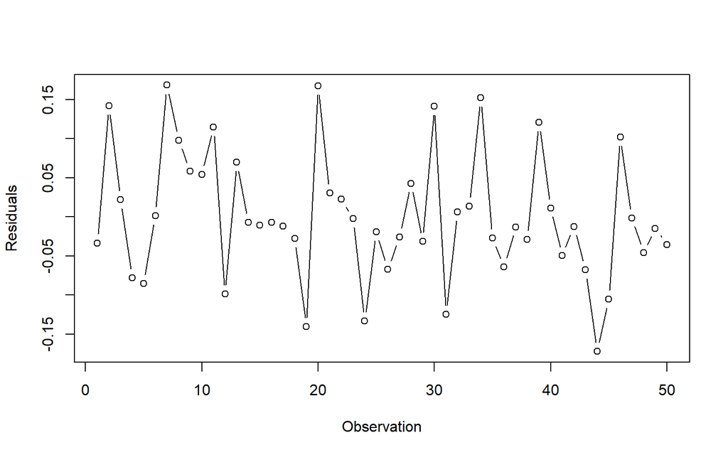

Plot Sisaan vs Urutan Pengamatan Setelah Transformasi

```r
plot(
  x = 1:dim(data2)[1],
  y = model3$residuals,
  type = "b",
  ylab = "Residuals",
  xlab = "Observation"
)
```

### 7.2.3 Normal Q-Q Plot

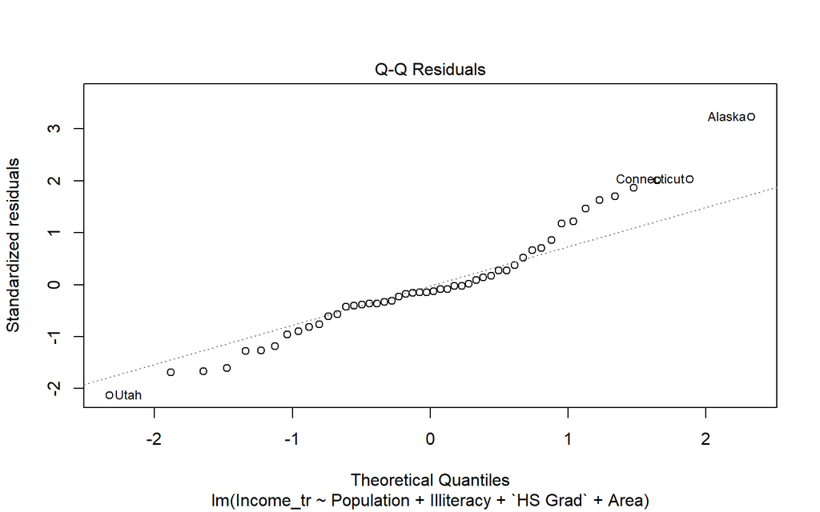

Normal Q-Q Plot Sisaan Setelah Transformasi

```r
plot(model3, 2)
```

## 7.3 Uji Formal Setelah Transformasi

### 7.3.1 Uji Nilai Harapan Sisaan

```r
t.test(model3$residuals, mu = 0, conf.level = 0.95)
```

```
#>
#>  One Sample t-test
#>
#> data:  model3$residuals
#> t = -3.4174e-17, df = 49, p-value = 1
#> alternative hypothesis: true mean is not equal to 0
#> 95 percent confidence interval:
#>  -0.02317146  0.02317146
#> sample estimates:
#>     mean of x
#> -3.940397e-19
```

Nilai-$p$ sama dengan $1$, yang lebih besar daripada $\alpha = 5\%$. Asumsi nilai harapan sisaan sama dengan nol **terpenuhi**.

### 7.3.2 Uji Homoskedastisitas

```r
bptest(model3)
```

```
#>
#>  studentized Breusch-Pagan test
#>
#> data:  model3
#> BP = 4.8087, df = 4, p-value = 0.3075
```

Nilai-$p$ sama dengan $0{,}3075$, yang lebih besar daripada $\alpha = 5\%$. Asumsi ragam sisaan homogen **terpenuhi**.

### 7.3.3 Uji Autokorelasi

```r
dwtest(model3)
```

```
#>
#>  Durbin-Watson test
#>
#> data:  model3
#> DW = 1.9726, p-value = 0.4624
#> alternative hypothesis: true autocorrelation is greater than 0
```

Nilai-$p$ sama dengan $0{,}4624$, yang lebih besar daripada $\alpha = 5\%$. Asumsi sisaan saling bebas **terpenuhi**.

### 7.3.4 Uji Normalitas

```r
lillie.test(model3$residuals)
```

```
#>
#>  Lilliefors (Kolmogorov-Smirnov) normality test
#>
#> data:  model3$residuals
#> D = 0.11324, p-value = 0.1124
```

Nilai-$p$ pada uji Lilliefors sama dengan $0{,}1124$, yang lebih besar daripada $\alpha = 5\%$. Asumsi **normalitas sisaan terpenuhi**, yang menunjukkan bahwa transformasi Box-Cox berhasil mengatasi permasalahan pelanggaran asumsi.

# 8 Transformasi Balik

# 9 Simpulan

Berdasarkan analisis yang telah dilakukan, dapat disimpulkan beberapa hal sebagai berikut:

1. Model regresi linear awal yang dibangun dengan data `state.x77` mengalami pelanggaran asumsi normalitas sisaan berdasarkan uji Lilliefors.
2. Tiga peubah penjelas terpilih melalui proses seleksi peubah (*backward*, *forward*, dan *stepwise*) yang menghasilkan kombinasi peubah yang konsisten, yaitu `Population`, `HS Grad`, dan `Area`.
3. Transformasi Box-Cox dengan $\lambda$ optimum sebesar $0{,}18182$ berhasil mengatasi pelanggaran asumsi normalitas sisaan, sekaligus meningkatkan nilai *adjusted* $R^2$ model dari $44{,}62\%$ menjadi $46{,}81\%$.
4. Seluruh asumsi klasik regresi linear terpenuhi setelah dilakukan transformasi Box-Cox pada peubah respons.
5. Transformasi balik dapat dilakukan jika ingin menginterpretasikan model dalam skala asli peubah respons.